# Activity_Course 2 Automatidata project lab

## PACE: **Analyze**

### **Task 2a. Build dataframe**

Create a pandas dataframe for data learning, exploratory data analysis (EDA), and statistical activities.

**Code the following,**

- import pandas as pd #library exercise for buidling dataframes
- import numpy as np #numpy is imported with pandas
- import matplotlib.pyplot as plt #visualization library
- import seaborn as sns #visualization library
- df = pd.read_csv('2017_Yellow_Taxi_Trip_Data.csv')

**Note:** pair the data object name "df" with pandas functions to manipulate data, such as df.groupby(). **Note:** As shown in this cell, the dataset has been automatically loaded in for you. You do not need to download the .csv file, or provide more code, in order to access the dataset and proceed with this lab. Please continue with this activity by completing the following instructions.

```python
#==> ENTER YOUR CODE OR RESPONSE HERE

import pandas as pd
import numpy as np
import matplotlib.pyplot as plt
import seaborn as sns

# RUN THIS CELL TO IMPORT YOUR DATA.
df = pd.read_csv('2017_Yellow_Taxi_Trip_Data.csv')
```

### **Task 2b. Understand the data - Interpret the data table**

View and interpret the datasets data table by **coding the following,**

1. df.head(10)
2. df.info()

*Consider the following two questions:*

**Question 1:** When reviewing the df.head() output, are there any data points that surprise you or are not correct?

**Question 2:** When reviewing the df.info output, What kind of data types are we working with?

```python
#==> ENTER YOUR CODE OR RESPONSE HERE

df.head(10)
```

|  | Unnamed: 0 | VendorID | tpep_pickup_datetime | tpep_dropoff_datetime | passenger_count | trip_distance | RatecodeID | store_and_fwd_flag | PULocationID | DOLocationID | payment_type | fare_amount | extra | mta_tax | tip_amount | tolls_amount | improvement_surcharge | total_amount |
| --- | --- | --- | --- | --- | --- | --- | --- | --- | --- | --- | --- | --- | --- | --- | --- | --- | --- | --- |
| 0 | 24870114 | 2 | 03/25/2017 8:55:43 AM | 03/25/2017 9:09:47 AM | 6 | 3.34 | 1 | N | 100 | 231 | 1 | 13.0 | 0.0 | 0.5 | 2.76 | 0.0 | 0.3 | 16.56 |
| 1 | 35634249 | 1 | 04/11/2017 2:53:28 PM | 04/11/2017 3:19:58 PM | 1 | 1.80 | 1 | N | 186 | 43 | 1 | 16.0 | 0.0 | 0.5 | 4.00 | 0.0 | 0.3 | 20.80 |
| 2 | 106203690 | 1 | 12/15/2017 7:26:56 AM | 12/15/2017 7:34:08 AM | 1 | 1.00 | 1 | N | 262 | 236 | 1 | 6.5 | 0.0 | 0.5 | 1.45 | 0.0 | 0.3 | 8.75 |
| 3 | 38942136 | 2 | 05/07/2017 1:17:59 PM | 05/07/2017 1:48:14 PM | 1 | 3.70 | 1 | N | 188 | 97 | 1 | 20.5 | 0.0 | 0.5 | 6.39 | 0.0 | 0.3 | 27.69 |
| 4 | 30841670 | 2 | 04/15/2017 11:32:20 PM | 04/15/2017 11:49:03 PM | 1 | 4.37 | 1 | N | 4 | 112 | 2 | 16.5 | 0.5 | 0.5 | 0.00 | 0.0 | 0.3 | 17.80 |
| 5 | 23345809 | 2 | 03/25/2017 8:34:11 PM | 03/25/2017 8:42:11 PM | 6 | 2.30 | 1 | N | 161 | 236 | 1 | 9.0 | 0.5 | 0.5 | 2.06 | 0.0 | 0.3 | 12.36 |
| 6 | 37660487 | 2 | 05/03/2017 7:04:09 PM | 05/03/2017 8:03:47 PM | 1 | 12.83 | 1 | N | 79 | 241 | 1 | 47.5 | 1.0 | 0.5 | 9.86 | 0.0 | 0.3 | 59.16 |
| 7 | 69059411 | 2 | 08/15/2017 5:41:06 PM | 08/15/2017 6:03:05 PM | 1 | 2.98 | 1 | N | 237 | 114 | 1 | 16.0 | 1.0 | 0.5 | 1.78 | 0.0 | 0.3 | 19.58 |
| 8 | 8433159 | 2 | 02/04/2017 4:17:07 PM | 02/04/2017 4:29:14 PM | 1 | 1.20 | 1 | N | 234 | 249 | 2 | 9.0 | 0.0 | 0.5 | 0.00 | 0.0 | 0.3 | 9.80 |
| 9 | 95294817 | 1 | 11/10/2017 3:20:29 PM | 11/10/2017 3:40:55 PM | 1 | 1.60 | 1 | N | 239 | 237 | 1 | 13.0 | 0.0 | 0.5 | 2.75 | 0.0 | 0.3 | 16.55 |

```python
#==> ENTER YOUR CODE OR RESPONSE HERE

df.info
```

```
<bound method DataFrame.info of        Unnamed: 0  VendorID    tpep_pickup_datetime   tpep_dropoff_datetime  \
0        24870114         2   03/25/2017 8:55:43 AM   03/25/2017 9:09:47 AM
1        35634249         1   04/11/2017 2:53:28 PM   04/11/2017 3:19:58 PM
2       106203690         1   12/15/2017 7:26:56 AM   12/15/2017 7:34:08 AM
3        38942136         2   05/07/2017 1:17:59 PM   05/07/2017 1:48:14 PM
4        30841670         2  04/15/2017 11:32:20 PM  04/15/2017 11:49:03 PM
...           ...       ...                     ...                     ...
22694    14873857         2   02/24/2017 5:37:23 PM   02/24/2017 5:40:39 PM
22695    66632549         2   08/06/2017 4:43:59 PM   08/06/2017 5:24:47 PM
22696    74239933         2   09/04/2017 2:54:14 PM   09/04/2017 2:58:22 PM
22697    60217333         2  07/15/2017 12:56:30 PM   07/15/2017 1:08:26 PM
22698    17208911         1   03/02/2017 1:02:49 PM   03/02/2017 1:16:09 PM

       passenger_count  trip_distance  RatecodeID store_and_fwd_flag  \
0                    6           3.34           1                  N
```

[output cut: 38 more lines]

### **Task 2c. Understand the data - Sort by variables**

Sort and interpret the data table for two variables of your choice.

**Answer the following three questions:**

**Question 1:** Sort your first variable (`trip_distance`) from maximum to minimum value, do the values seem normal?

**Question 2:** Sort your by your second variable (`total_amount`), are any values unusual?

**Question 3:** Are the resulting rows similar for both sorts? Why or why not?

```python
#==> Enter your code here to sort your first variable.

df = df.sort_values(by='trip_distance', ascending=False)
df
```

|  | Unnamed: 0 | VendorID | tpep_pickup_datetime | tpep_dropoff_datetime | passenger_count | trip_distance | RatecodeID | store_and_fwd_flag | PULocationID | DOLocationID | payment_type | fare_amount | extra | mta_tax | tip_amount | tolls_amount | improvement_surcharge | total_amount |
| --- | --- | --- | --- | --- | --- | --- | --- | --- | --- | --- | --- | --- | --- | --- | --- | --- | --- | --- |
| 9280 | 51810714 | 2 | 06/18/2017 11:33:25 PM | 06/19/2017 12:12:38 AM | 2 | 33.96 | 5 | N | 132 | 265 | 2 | 150.00 | 0.0 | 0.0 | 0.00 | 0.00 | 0.3 | 150.30 |
| 13861 | 40523668 | 2 | 05/19/2017 8:20:21 AM | 05/19/2017 9:20:30 AM | 1 | 33.92 | 5 | N | 229 | 265 | 1 | 200.01 | 0.0 | 0.5 | 51.64 | 5.76 | 0.3 | 258.21 |
| 6064 | 49894023 | 2 | 06/13/2017 12:30:22 PM | 06/13/2017 1:37:51 PM | 1 | 32.72 | 3 | N | 138 | 1 | 1 | 107.00 | 0.0 | 0.0 | 55.50 | 16.26 | 0.3 | 179.06 |
| 10291 | 76319330 | 2 | 09/11/2017 11:41:04 AM | 09/11/2017 12:18:58 PM | 1 | 31.95 | 4 | N | 138 | 265 | 2 | 131.00 | 0.0 | 0.5 | 0.00 | 0.00 | 0.3 | 131.80 |
| 29 | 94052446 | 2 | 11/06/2017 8:30:50 PM | 11/07/2017 12:00:00 AM | 1 | 30.83 | 1 | N | 132 | 23 | 1 | 80.00 | 0.5 | 0.5 | 18.56 | 11.52 | 0.3 | 111.38 |
| ... | ... | ... | ... | ... | ... | ... | ... | ... | ... | ... | ... | ... | ... | ... | ... | ... | ... | ... |
| 2150 | 57739826 | 2 | 07/06/2017 9:13:14 PM | 07/06/2017 9:13:18 PM | 6 | 0.00 | 1 | N | 264 | 141 | 1 | 2.50 | 0.5 | 0.5 | 0.95 | 0.00 | 0.3 | 4.75 |
| 5798 | 10156310 | 2 | 02/12/2017 1:00:08 AM | 02/12/2017 1:00:28 AM | 1 | 0.00 | 1 | N | 231 | 211 | 2 | 2.50 | 0.5 | 0.5 | 0.00 | 0.00 | 0.3 | 3.80 |
| 920 | 92102517 | 2 | 10/31/2017 8:29:53 PM | 10/31/2017 8:30:27 PM | 1 | 0.00 | 1 | N | 50 | 50 | 2 | 2.50 | 0.5 | 0.5 | 0.00 | 0.00 | 0.3 | 3.80 |
| 17654 | 24874216 | 2 | 03/25/2017 9:21:00 AM | 03/25/2017 9:21:03 AM | 4 | 0.00 | 2 | N | 234 | 234 | 2 | 52.00 | 0.0 | 0.5 | 0.00 | 0.00 | 0.3 | 52.80 |
| 17788 | 58079289 | 1 | 07/08/2017 12:54:02 AM | 07/08/2017 12:55:03 AM | 2 | 0.00 | 1 | N | 158 | 158 | 3 | 2.50 | 0.5 | 0.5 | 0.00 | 0.00 | 0.3 | 3.80 |

22699 rows × 18 columns

```python
#==> Enter your code here to sort your second variable.

df = df.sort_values(by='total_amount', ascending=False)
df
```

|  | Unnamed: 0 | VendorID | tpep_pickup_datetime | tpep_dropoff_datetime | passenger_count | trip_distance | RatecodeID | store_and_fwd_flag | PULocationID | DOLocationID | payment_type | fare_amount | extra | mta_tax | tip_amount | tolls_amount | improvement_surcharge | total_amount |
| --- | --- | --- | --- | --- | --- | --- | --- | --- | --- | --- | --- | --- | --- | --- | --- | --- | --- | --- |
| 8476 | 11157412 | 1 | 02/06/2017 5:50:10 AM | 02/06/2017 5:51:08 AM | 1 | 2.60 | 5 | N | 226 | 226 | 1 | 999.99 | 0.0 | 0.0 | 200.00 | 0.00 | 0.3 | 1200.29 |
| 20312 | 107558404 | 2 | 12/19/2017 9:40:46 AM | 12/19/2017 9:40:55 AM | 2 | 0.00 | 5 | N | 265 | 265 | 2 | 450.00 | 0.0 | 0.0 | 0.00 | 0.00 | 0.3 | 450.30 |
| 13861 | 40523668 | 2 | 05/19/2017 8:20:21 AM | 05/19/2017 9:20:30 AM | 1 | 33.92 | 5 | N | 229 | 265 | 1 | 200.01 | 0.0 | 0.5 | 51.64 | 5.76 | 0.3 | 258.21 |
| 12511 | 107108848 | 2 | 12/17/2017 6:24:24 PM | 12/17/2017 6:24:42 PM | 1 | 0.00 | 5 | N | 265 | 265 | 1 | 175.00 | 0.0 | 0.0 | 46.69 | 11.75 | 0.3 | 233.74 |
| 15474 | 55538852 | 2 | 06/06/2017 8:55:01 PM | 06/06/2017 8:55:06 PM | 1 | 0.00 | 5 | N | 265 | 265 | 1 | 200.00 | 0.0 | 0.5 | 11.00 | 0.00 | 0.3 | 211.80 |
| ... | ... | ... | ... | ... | ... | ... | ... | ... | ... | ... | ... | ... | ... | ... | ... | ... | ... | ... |
| 14714 | 109276092 | 2 | 12/24/2017 10:37:58 PM | 12/24/2017 10:41:08 PM | 5 | 0.40 | 1 | N | 164 | 161 | 4 | -4.00 | -0.5 | -0.5 | 0.00 | 0.00 | -0.3 | -5.30 |
| 11204 | 58395501 | 2 | 07/09/2017 7:20:59 AM | 07/09/2017 7:23:50 AM | 1 | 0.64 | 1 | N | 50 | 48 | 3 | -4.50 | 0.0 | -0.5 | 0.00 | 0.00 | -0.3 | -5.30 |
| 17602 | 24690146 | 2 | 03/24/2017 7:31:13 PM | 03/24/2017 7:34:49 PM | 1 | 0.46 | 1 | N | 87 | 45 | 4 | -4.00 | -1.0 | -0.5 | 0.00 | 0.00 | -0.3 | -5.80 |
| 20698 | 14668209 | 2 | 02/24/2017 12:38:17 AM | 02/24/2017 12:42:05 AM | 1 | 0.70 | 1 | N | 65 | 25 | 4 | -4.50 | -0.5 | -0.5 | 0.00 | 0.00 | -0.3 | -5.80 |
| 12944 | 29059760 | 2 | 04/08/2017 12:00:16 AM | 04/08/2017 11:15:57 PM | 1 | 0.17 | 5 | N | 138 | 138 | 4 | -120.00 | 0.0 | 0.0 | 0.00 | 0.00 | -0.3 | -120.30 |

22699 rows × 18 columns

## PACE: **Construct**

### **Task 3a. Understand the data - View Descriptive statistics**

**Instructions:** Using pandas df.describe(), what is the min, mean, and max of your chosen variables?

**Code and perform the following,**

- df.describe()
- **Question 1:** What is the min, mean, and max of your first variable?
- **Question 2:** What is the min, mean, and max of second variable?
- **Question 3:** Are the values easily readable? Would could be done to make them more easily readable?

```python
#==> ENTER YOUR CODE OR RESPONSE HERE

#Question 1: what is the min, mean and max of your first variable ?

df['trip_distance'].describe()


#Question 2: what is the min, mean, and max of your second variable?

df['total_amount'].describe()
```

[output not shown]

```
count    22699.000000
mean        16.310502
std         16.097295
min       -120.300000
25%          8.750000
50%         11.800000
75%         17.800000
max       1200.290000
Name: total_amount, dtype: float64
```

### **Task 3b. Visualize your variables**

**Instructions:** Create a histogram for each of the two variables. Act and reflect on the following steps:

1. Histogram of your first variable (`total_amount`)
2. Histogram of your second variable (`trip_distance`)
3. Are your variables numerical (did the code work)?

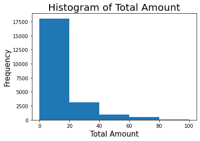

```python
#==> ENTER YOUR CODE OR RESPONSE TO VISUALIZE THE FIRST VARIABLE HERE

plt.hist(df['total_amount'], bins=[0,20,40,60,80,100])
plt.xlabel('Total Amount', fontsize=15)
plt.ylabel('Frequency', fontsize=15)
plt.title('Histogram of Total Amount', fontsize=20)
```

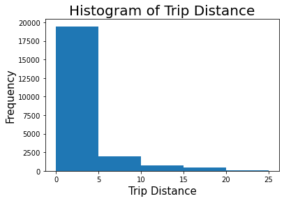

```python
#==> ENTER YOUR CODE OR RESPONSE TO VISUALIZE THE SECOND VARIABLE HERE

plt.hist(df['trip_distance'], bins=[0,5,10,15,20,25])
plt.xlabel('Trip Distance',fontsize=15)
plt.ylabel('Frequency',fontsize=15)
plt.title('Histogram of Trip Distance',fontsize=20)
```

## PACE: **Execute**

### **Given your efforts, what can you summarize for DeShawn and the data team?**

*Note for Learners: Your answer should address Luana's request for a summary that covers the following points:*

- A summary of the data types for each variable
- The minimum, mean, and max for the two variables
- Any relevant and irrelevant columns
- A summary of the data visualization